# Εξαγωγή δομημένης πληροφορίας από τίτλους τεκμηρίων της ΔΙΣ

## Στόχος

- χρήση της τεχνογνωσίας ΕΦΓ του ΙΕΛ/ΕΚ Αθηνά
- για την εξαγωγή δομημένης πληροφορίας από τίτλους τεκμηρίων της Διεύθυνσης Ιστορίας Στρατού (ΔΙΣ)

## Υλικό για το πείραμα

- Τίτλοι τεκμηρίων από το ψηφιοποιημένο αρχείο της [ΔΙΣ](http://disarxeio.army.gr:8888/dm-ext/doc-ext/search-documents-ext.jsf)
- 199 τίτλοι που εμπίπτουν σε 11 κατηγορίες τεκμηρίων

  ```
  ΑΝΑΦΟΡΑ ΑΤΟΜΙΚΗ, ΑΝΑΦΟΡΑ ΥΠΗΡΕΣΙΑΚΗ, ΔΙΑΤΑΓΗ, ΕΓΚΥΚΛΙΟΣ ΔΙΑΤΑΓΗ, ΕΚΘΕΣΗ, ΕΚΘΕΣΗ ΔΡΑΣΤΗΡΙΟΤΗΤΑΣ ΜΟΝΑΔΑΣ, ΕΠΙΣΗΜΟ ΜΗ ΣΤΡΑΤΙΩΤΙΚΟ ΕΓΓΡΑΦΟ, ΕΠΙΣΤΟΛΗ, ΣΗΜΑ, ΤΑΧΥ ΕΓΓΡΑΦΟ, ΥΠΗΡΕΣΙΑΚΟ ΣΗΜΕΙΩΜΑ
  ```

- Σε κεφαλαιογράμματη γραφή χωρίς τόνους
- Σχετικά μεγάλος αριθμός ονοματικών οντοτήτων (οργανισμών, προσώπων, τοποθεσιών, κ.α.) και συντομογραφιών

## Στάδια ανάλυσης

- Οι τίτλοι αναλύθηκαν αρχικά με τα βασικά εργαλεία επεξεργασίας φυσικής γλώσσας του ΙΕΛ. Συγκεκριμένα:
  - αναγνωρίστηκε το μέρος του λόγου και το λήμμα σε όλες τις λέξεις των τίτλων
  - o κάθε τίτλος χωρίστηκε σε φραστικά συστατικά.
- Αναπτύχθηκε και χρησιμοποιήθηκε ένα σύνολο από κανόνες με στόχο την εξαγωγή πληροφοριών που περιλαμβάνουν τα εξής:
  - τύπος του εγγράφου
  - αποστολέας
  - παραλήπτης
  - ημερομηνία αποστολής
  - θέμα του κάθε εγγράφου

## Παράδειγμα εισόδου/εξόδου

```
ΑΝΑΦΟΡΑ ΑΠΟ ΤΟ Γ' ΣΩΜΑ ΣΤΡΑΤΟΥ ΤΗΝ 18/01/1949 ΠΡΟΣ ΓΕΝΙΚΟ ΕΠΙΤΕΛΕΙΟ ΣΤΡΑΤΟΥ ΠΕΡΙ ΑΠΩΛΕΙΩΝ ΠΕΡΙΟΧΗΣ ΝΑΟΥΣΗΣ

DocType: ΑΝΑΦΟΡΑ
Date: ΤΗΝ 18/01/1949
Sender: ΑΠΟ ΤΟ Γ' ΣΩΜΑ ΣΤΡΑΤΟΥ
Addressee: ΠΡΟΣ ΓΕΝΙΚΟ ΕΠΙΤΕΛΕΙΟ ΣΤΡΑΤΟΥ
Subject: ΠΕΡΙ ΑΠΩΛΕΙΩΝ ΠΕΡΙΟΧΗΣ ΝΑΟΥΣΗΣ
```

## Αποτελέσματα σε υποσύνολο του υλικού

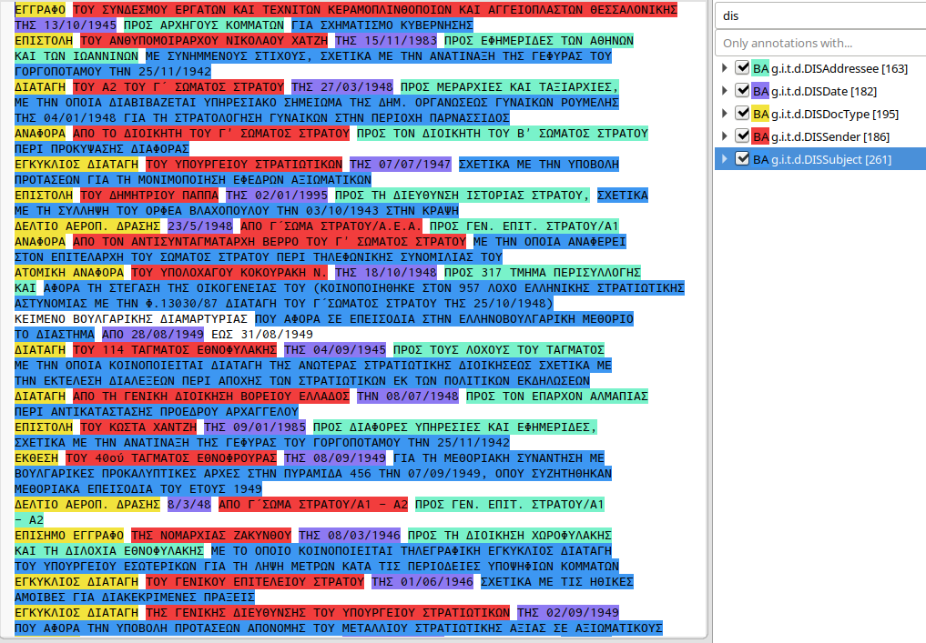

## Πρώτα συμπεράσματα

- Ενθαρρυντικά αποτελέσματα στο συγκεκριμένο δείγμα.
- Η πρόσβαση στο σύνολο του υλικού θα επιτρέψει να προχωρήσουμε
  - σε επισημάνσεις πιθανών υψίσυχνων προβλημάτων και
  - σε προσαρμογές στους κανόνες ή/και στη βασική επεξεργασία

## Προεκτάσεις

- Σε επόμενα πειράματα θα μπορούσε επίσης να εξεταστεί η χρησιμότητα και η ακρίβεια τεχνικών κανονικοποίησης όπως:
- η αφαίρεση δεικτών (π.χ. `ΠΡΟΣ, ΣΧΕΤΙΚΑ ΜΕ`)
- η μεταγραφή κεφαλαίων σε πεζά (π.χ. `ΣΤΗ ΔΥΤΙΚΗ ΜΑΚΕΔΟΝΙΑ -> στη Δυτική Μακεδονία`) και
- η μετατροπή ονοματικών φράσεων από αιτιατική και γενική πτώση σε ονομαστική, όπου αυτό είναι χρήσιμο (π.χ. `ΓΙΑ ΤΟΝ ΣΧΗΜΑΤΙΣΜΟ ΚΥΒΕΡΝΗΣΗΣ -> σχηματισμός κυβέρνησης`)